# Project Python Foundations: FoodHub Data Analysis

**Marks: 60**

### Context

The number of restaurants in New York is increasing day by day. Lots of students and busy professionals rely on those restaurants due to their hectic lifestyles. Online food delivery service is a great option for them. It provides them with good food from their favorite restaurants. A food aggregator company FoodHub offers access to multiple restaurants through a single smartphone app.

The app allows the restaurants to receive a direct online order from a customer. The app assigns a delivery person from the company to pick up the order after it is confirmed by the restaurant. The delivery person then uses the map to reach the restaurant and waits for the food package. Once the food package is handed over to the delivery person, he/she confirms the pick-up in the app and travels to the customer's location to deliver the food. The delivery person confirms the drop-off in the app after delivering the food package to the customer. The customer can rate the order in the app. The food aggregator earns money by collecting a fixed margin of the delivery order from the restaurants.

### Objective

The food aggregator company has stored the data of the different orders made by the registered customers in their online portal. They want to analyze the data to get a fair idea about the demand of different restaurants which will help them in enhancing their customer experience. Suppose you are hired as a Data Scientist in this company and the Data Science team has shared some of the key questions that need to be answered. Perform the data analysis to find answers to these questions that will help the company to improve the business.

### Data Description

The data contains the different data related to a food order. The detailed data dictionary is given below.

### Data Dictionary

- order_id: Unique ID of the order
- customer_id: ID of the customer who ordered the food
- restaurant_name: Name of the restaurant
- cuisine_type: Cuisine ordered by the customer
- cost: Cost of the order
- day_of_the_week: Indicates whether the order is placed on a weekday or weekend (The weekday is from Monday to Friday and the weekend is Saturday and Sunday)
- rating: Rating given by the customer out of 5
- food_preparation_time: Time (in minutes) taken by the restaurant to prepare the food. This is calculated by taking the difference between the timestamps of the restaurant's order confirmation and the delivery person's pick-up confirmation.
- delivery_time: Time (in minutes) taken by the delivery person to deliver the food package. This is calculated by taking the difference between the timestamps of the delivery person's pick-up confirmation and drop-off information

### Let us start by importing the required libraries

```python
# import necessary libraries for data manipulation and visualization
import numpy as np
import pandas as pd
import matplotlib.pyplot as plt
import seaborn as sns
```

```python
# import warnings to suppress userWarnings etc.
import warnings as w
```

### Understanding the structure of the data

```python
# mount the drive for Google Colab
from google.colab import drive
drive.mount('/content/drive')
```

```python
# load and read data
df = pd.read_csv('/content/drive/MyDrive/AIML_UTA/Python Foundation/Project/foodhub_order.csv')
# returns the first 5 rows of the data set
df.head(5)
```

|  | order_id | customer_id | restaurant_name | cuisine_type | cost_of_the_order | day_of_the_week | rating | food_preparation_time | delivery_time |
| --- | --- | --- | --- | --- | --- | --- | --- | --- | --- |
| 0 | 1477147 | 337525 | Hangawi | Korean | 30.75 | Weekend | Not given | 25 | 20 |
| 1 | 1477685 | 358141 | Blue Ribbon Sushi Izakaya | Japanese | 12.08 | Weekend | Not given | 25 | 23 |
| 2 | 1477070 | 66393 | Cafe Habana | Mexican | 12.23 | Weekday | 5 | 23 | 28 |
| 3 | 1477334 | 106968 | Blue Ribbon Fried Chicken | American | 29.20 | Weekend | 3 | 25 | 15 |
| 4 | 1478249 | 76942 | Dirty Bird to Go | American | 11.59 | Weekday | 4 | 25 | 24 |

**Observations**

The DataFrame has 9 columns as mentioned in the Data Dictionary. Data in each row corresponds to the order placed by a customer.

### **Question 1:** How many rows and columns are present in the data? [0.5 mark]

```python
# Let's check how many rows and columns in the data set
df.shape
```

```
(1898, 9)
```

**Observations**:

There are 1898 rows and 9 columns in the dataset.

### **Question 2:** What are the datatypes of the different columns in the dataset? (The info() function can be used) [0.5 mark]

```python
# Let's check the summary of the DataFrame, columns, non-null count and the data type
df.info()
```

```
<class 'pandas.core.frame.DataFrame'>
RangeIndex: 1898 entries, 0 to 1897
Data columns (total 9 columns):
 #   Column                 Non-Null Count  Dtype
---  ------                 --------------  -----
 0   order_id               1898 non-null   int64
 1   customer_id            1898 non-null   int64
 2   restaurant_name        1898 non-null   object
 3   cuisine_type           1898 non-null   object
 4   cost_of_the_order      1898 non-null   float64
 5   day_of_the_week        1898 non-null   object
 6   rating                 1898 non-null   object
 7   food_preparation_time  1898 non-null   int64
 8   delivery_time          1898 non-null   int64
dtypes: float64(1), int64(4), object(4)
memory usage: 133.6+ KB
```

**Observations**:

1. There are no missing values in the dataset
2. Data belong to 3 data types, 4 columns of integers, 4 columns of object data type and 1 column of float type.
3. Data frame uses 133.6+ KB of space

### **Question 3:** Are there any missing values in the data? If yes, treat them using an appropriate method. [1 mark]

```python
# Let's check if we have any missing values
df.isna().sum()
```

```
order_id                 0
customer_id              0
restaurant_name          0
cuisine_type             0
cost_of_the_order        0
day_of_the_week          0
rating                   0
food_preparation_time    0
delivery_time            0
dtype: int64
```

**Observations**:

- There are no missing values in the dataset.

```python
# check whether there are any duplicates in the data.
df.duplicated().sum()
```

```
0
```

**Observations**:

- There are no duplicates in the data.

### **Question 4:** Check the statistical summary of the data. What is the minimum, average, and maximum time it takes for food to be prepared once an order is placed? [2 marks]

```python
# Let's check the statistical summary of the data set, include all the variables
df.describe(include='all').T
```

|  | count | unique | top | freq | mean | std | min | 25% | 50% | 75% | max |
| --- | --- | --- | --- | --- | --- | --- | --- | --- | --- | --- | --- |
| order_id | 1898.0 | NaN | NaN | NaN | 1477495.5 | 548.049724 | 1476547.0 | 1477021.25 | 1477495.5 | 1477969.75 | 1478444.0 |
| customer_id | 1898.0 | NaN | NaN | NaN | 171168.478398 | 113698.139743 | 1311.0 | 77787.75 | 128600.0 | 270525.0 | 405334.0 |
| restaurant_name | 1898 | 178 | Shake Shack | 219 | NaN | NaN | NaN | NaN | NaN | NaN | NaN |
| cuisine_type | 1898 | 14 | American | 584 | NaN | NaN | NaN | NaN | NaN | NaN | NaN |
| cost_of_the_order | 1898.0 | NaN | NaN | NaN | 16.498851 | 7.483812 | 4.47 | 12.08 | 14.14 | 22.2975 | 35.41 |
| day_of_the_week | 1898 | 2 | Weekend | 1351 | NaN | NaN | NaN | NaN | NaN | NaN | NaN |
| rating | 1898 | 4 | Not given | 736 | NaN | NaN | NaN | NaN | NaN | NaN | NaN |
| food_preparation_time | 1898.0 | NaN | NaN | NaN | 27.37197 | 4.632481 | 20.0 | 23.0 | 27.0 | 31.0 | 35.0 |
| delivery_time | 1898.0 | NaN | NaN | NaN | 24.161749 | 4.972637 | 15.0 | 20.0 | 25.0 | 28.0 | 33.0 |

**Observations:**

- Minimum food preparation time is 20 minutes.
- Average food preparation time is 27 minutes.
- Maximum food preparation time is 35 minutes.

### **Question 5:** How many orders are not rated? [1 mark]

```python
# Let's check the what are the unique values in rating and their count to find the not rated count
df['rating'].value_counts()
```

```
rating
Not given    736
5            588
4            386
3            188
Name: count, dtype: int64
```

**Observations:**

- There are 736 orders that are not rated.

### Exploratory Data Analysis (EDA)

### **Question 6:** Explore all the variables and provide observations on their distributions. (Generally, histograms, boxplots, countplots, etc. are used for univariate exploration.) [9 marks]

**Observations on order_id:**

```python
# Let's check unique order id
df['order_id'].nunique()
```

```
1898
```

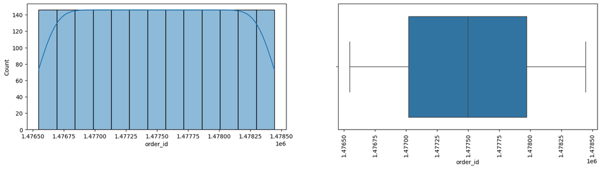

```python
# we don't normally plot id columns, but since the instructions are given to evaluate all the variables just plotted them.
fig, axes = plt.subplots(1, 2, figsize=(18, 4))

sns.histplot(ax=axes[0], data=df,x='order_id', kde=True)
plt.xticks(rotation=90)
sns.boxplot(ax=axes[1], data=df,x='order_id')
plt.xticks(rotation=90)
plt.show()
```

**Observations on order_id:**

- There are 1898 unique order ids in the data set.
- Histplot was used instead of countplot to avaoid clutter. Histogram will help arrange the ids in bins based on the number.
- Order_id has a uniform distribution, because the variable is an unique identifier.

**Observations on customer_id:**

```python
# Let's check how many unique customer id are there
df['customer_id'].nunique()
```

```
1200
```

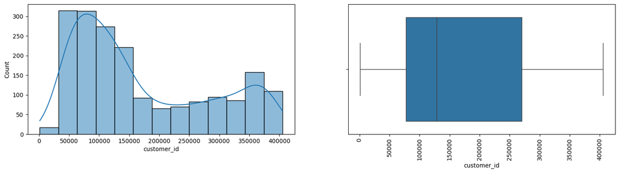

```python
# Let's plot the customer ids
fig, axes = plt.subplots(1, 2, figsize=(18, 4))

sns.histplot(ax=axes[0], data=df,x='customer_id', kde=True)
plt.xticks(rotation=90)
sns.boxplot(ax=axes[1], data=df,x='customer_id')
plt.xticks(rotation=90)
plt.show()
```

**Observations on customer_id:**

- There are only 1200 unique customer id in the data set
- Histplot s used instead of countplot to avoid clutter. Histogram will help arrange the ids in bins based on the number.
- Customer_id shows a binomial distribution, but it has no meaning because the variable is an unique identifier. According to this plot some of the customers have placed orders more frequently as showed by the two peaks, than some random customers who might be not regular customers. Data shows no outliers.

**Observations on restaurant_name:**

```python
# Let's check how many restaurants are there
df['restaurant_name'].nunique()
```

```
178
```

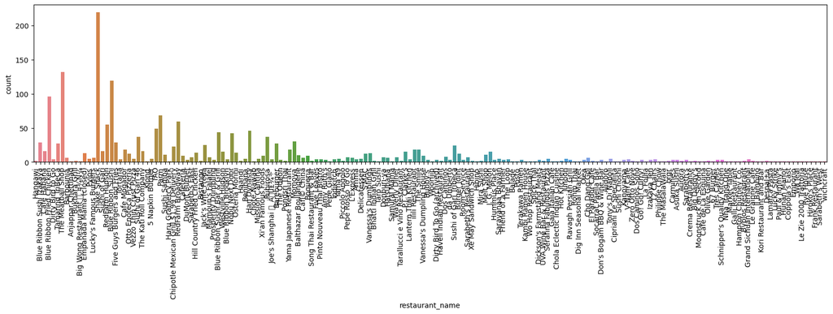

```python
# Plot the restaurants to get the frequency in each
plt.figure(figsize=(20,4))
sns.countplot(data=df,x='restaurant_name', hue='restaurant_name')
plt.xticks(rotation=90)
plt.show()
w.filterwarnings('ignore');  # suppressed an user warning
```

**Observations on restaurant_name:**

- There are 178 unique restaurants in the data set
- Some of the restaurants are very popular. Shake Shack, The Meatball Shop, Blue Ribbon Sushi, and Blue Ribbon Fried Chicken are the top 4 restaurants based on order counts.

**Observations on cuisine_type:**

```python
# Number of unique cuisine types
df['cuisine_type'].nunique()
```

```
14
```

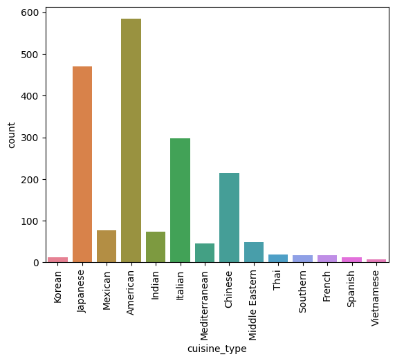

```python
# Let's check the cuisine types for their frequencies in each
sns.countplot(data=df,x='cuisine_type', hue='cuisine_type')
plt.xticks(rotation=90)
plt.show()
```

**Observations on cuisine_type:**

- There are 14 cuisine types
- American cuisines are preferred by most customers. The next favorite food type is Japanese food.
- Customers prefer Italian food over Chinese food.
- Preference for the Mexican and Indian food are similar.